# State Farm Data Challenge

*Jeffrey Box* 11-05-18

**Full project link:** https://www.dropbox.com/s/v85xylotjph54pi/StateFarm_Data_Challenge_Jeff_Box_11052018.zip?dl=0

**Objectives:**

- Build two distinctly different machine learning/statistical models
- Create two outputs of predictions: class probabilities for belonging to the positive class

## Before you start

This project requires Python 3.6, Jupyter, and various Python libraries. Please ensure you are properly setup: In your shell:navigate to the resources folder provided, create a new python environment from my requirements file, and then activate. Change the directory to deliverables, and then start Jupyter.

- shell: cd … /StateFarm/Resources'
- shell: conda env create --file statefarm_env_setup.txt
- shell: source activate statefarm
- shell: cd ../Deliverables
- shell: jupyter notebook

## Introduction

**Objectives**

1. Build two distinctly different machine learning/statistical models
2. Two outputs of predictions: class probabilities for belonging to the positive class

**Resources**

- “exercise_03_test.csv”
- “exercise_03_train.csv”
- No additional data may be added or used
- Not all data must be used

## Methodology

I follow an analytics paradigm when solving *any* problem end-to-end answering ‘why?’, ‘how?’, and ‘what?’. Doing this ensures three things: 1) process efficiency 2) error-reduction in analysis 3) and most importantly, a value-driven outcome.

### Why

**Decompose the “Ask”, and understand the data**  
The ask was given. Build two different Machine Learning (ML) models and create predictions based on test data.

**Identify the data source**  
The training and test sets were provided in two separate CSV files.

**Strategy**  
Because we know the data labels and the requested output, this is a Supervised ML problem: *We are trying to predict Y given 100 features, X0 - x99.*

### How

**Data retrieval plan and retrieval**  
The data was provided. Pandas will be used to read the CSV in Python and gain insights about the data. However, some data transformation is required to get the data in a format needed for our ML model. That is the extent of ETL for this project.

### What

**Analysis**

**Limitations & future considerations**

- Experiment with using an imputer instead of simply dropping nulls.
- Note that because exercise_03_test.csv removed ‘y’ (aka y_test), it is impossible to calculate model accuracy or residuals.
- This code takes approximately 6 minutes to run top to bottom. This is a potential concern for scaling.
- Because the instructions specify to use only 2 models, I chose logistic regression and random forest classifier due to their simplicity and ability to perform the task required. Looking at other models and doing a series of nearest neighbor classifications would be useful as well.

## Results

Both models produce csv files of the probabilities utilizing the built-in predict_proba(X) method. The outputs differ between models, but by visualizing, we can see a relationship between the two prediction sets.

```python
# Code Dependencies
%matplotlib inline
import matplotlib.pyplot as plt
import numpy as np
import pandas as pd
import os

# ML Dependencies
import sklearn
from sklearn.model_selection import train_test_split
from sklearn.preprocessing import StandardScaler
from sklearn.metrics import mean_squared_error
from sklearn.linear_model import LogisticRegression
from sklearn.ensemble import RandomForestClassifier
```

## LOAD

- Read in the dataset; clean if necessary
- Gain insight about the dataset

```python
# Read the csv file into a pandas DataFrame
test_csv = pd.read_csv('../Data/exercise_03_test.csv')
train_csv = pd.read_csv('../Data/exercise_03_train.csv')
```

```python
test_csv.head()
```

|  | x0 | x1 | x2 | x3 | x4 | x5 | x6 | x7 | x8 | x9 | ... | x90 | x91 | x92 | x93 | x94 | x95 | x96 | x97 | x98 | x99 |
| --- | --- | --- | --- | --- | --- | --- | --- | --- | --- | --- | --- | --- | --- | --- | --- | --- | --- | --- | --- | --- | --- |
| 0 | 120.252886 | -0.170668 | 20.710224 | -13.409410 | -20.148997 | 18.649383 | 0.015563 | 0.799069 | 27.749853 | 0.457208 | ... | -42.154991 | -5.020444 | 0.142960 | asia | 12.202997 | 17.206558 | -6.698424 | 10.669022 | 0.535953 | 0.794408 |
| 1 | 151.496163 | -0.065142 | -1.423250 | 9.250107 | -58.582435 | -3.730727 | 0.469421 | 2.994060 | -74.308495 | 6.637583 | ... | -98.797446 | -2.605834 | 4.222651 | asia | 0.865352 | -31.330463 | 9.030439 | 1.769777 | -0.265219 | -2.511831 |
| 2 | -46.054317 | -0.174997 | 9.167775 | 7.611975 | -33.043372 | -2.258558 | -0.308114 | -8.216299 | -10.016635 | -2.693126 | ... | -246.457481 | -3.404679 | -4.384774 | asia | -7.693588 | -12.767262 | -8.578260 | 0.202378 | -0.901658 | 0.340148 |
| 3 | -7.784201 | -0.201334 | 24.985110 | 21.561477 | 5.953458 | 9.298979 | 0.061949 | -1.028978 | -46.827620 | 3.482482 | ... | 301.527167 | 1.474712 | 6.158162 | asia | 3.072433 | 41.619199 | -0.255531 | 1.704807 | 0.514364 | -9.247276 |
| 4 | -16.692351 | -0.602332 | -16.602345 | 41.147584 | 9.405121 | -59.245570 | -0.524156 | -6.817356 | 17.554925 | 4.143827 | ... | 208.742875 | 3.752589 | 2.435466 | asia | -3.313370 | -18.762901 | -14.614473 | 17.928303 | 0.355491 | 7.571392 |

5 rows × 100 columns

```python
train_csv.head()
```

|  | x0 | x1 | x2 | x3 | x4 | x5 | x6 | x7 | x8 | x9 | ... | x91 | x92 | x93 | x94 | x95 | x96 | x97 | x98 | x99 | y |
| --- | --- | --- | --- | --- | --- | --- | --- | --- | --- | --- | --- | --- | --- | --- | --- | --- | --- | --- | --- | --- | --- |
| 0 | 83.812330 | -0.122672 | 65.391785 | 6.323478 | -18.511031 | 2.122648 | 0.319472 | 7.650422 | 7.713315 | 2.789856 | ... | 5.482352 | 12.211997 | asia | -3.201565 | -9.837196 | -21.092011 | 4.671140 | 0.588994 | -11.417083 | 0 |
| 1 | -0.445312 | -0.436077 | 12.981759 | 30.716674 | -34.981679 | -16.712862 | 0.530105 | 8.740222 | 56.044533 | 0.075118 | ... | -6.083035 | -5.098374 | asia | 5.433036 | 91.724841 | 4.305371 | 4.329130 | 0.371513 | 8.474528 | 0 |
| 2 | 82.927148 | 0.075277 | -29.096012 | -20.176841 | 10.109713 | -45.994005 | 0.618132 | 7.757838 | -69.749060 | -1.561335 | ... | 0.200787 | -7.174907 | asia | 2.595005 | -14.630603 | -3.743052 | -14.820376 | -2.366675 | 2.613091 | 0 |
| 3 | 370.736586 | -0.263338 | -75.273905 | -21.765844 | -72.478339 | -8.701108 | 0.332586 | 2.769763 | -35.815423 | 5.230400 | ... | 4.986738 | -6.649765 | asia | 4.349013 | -53.825281 | -12.243755 | -4.257462 | -0.352829 | -9.641206 | 0 |
| 4 | 33.775263 | -0.270047 | -40.486723 | 3.990431 | -13.733621 | -6.185321 | -0.733206 | -3.325673 | -5.055036 | -4.331587 | ... | 3.793349 | -0.865512 | asia | 4.432424 | 8.605707 | -23.823016 | -11.913495 | -0.139055 | -0.318227 | 0 |

5 rows × 101 columns

```python
test_csv.info()
```

[output not shown]

```python
train_csv.info()
```

```
<class 'pandas.core.frame.DataFrame'>
RangeIndex: 40000 entries, 0 to 39999
Columns: 101 entries, x0 to y
dtypes: float64(94), int64(1), object(6)
memory usage: 30.8+ MB
```

## PREPARE

- Clean the dataset by dropping nulls
- Quantify the qualitative data
- Create the train and test sets

```python
# Drop nulls is sufficient, because it's a small enough N for train and test
# training = 796 records with at least one empty value
# test = 204 records with at least one empty value
train_csv = train_csv.dropna()
test_csv = test_csv.dropna()
# test_csv.info()
# train_csv.info()
```

```python
# Remove "$" from x41 and convert to a float
train_csv['x41'] = train_csv['x41'].str.replace('$', '')
train_csv['x41'] = train_csv['x41'].astype(float)
test_csv['x41'] = test_csv['x41'].str.replace('$', '')
test_csv['x41'] = test_csv['x41'].astype(float)
```

```python
# dummy data for qualitative features
# Note: We've gone from 99 features to 139
train_csv = pd.get_dummies(train_csv)
train_csv.head()
```

|  | x0 | x1 | x2 | x3 | x4 | x5 | x6 | x7 | x8 | x9 | ... | x68_July | x68_Jun | x68_Mar | x68_May | x68_Nov | x68_Oct | x68_sept. | x93_america | x93_asia | x93_euorpe |
| --- | --- | --- | --- | --- | --- | --- | --- | --- | --- | --- | --- | --- | --- | --- | --- | --- | --- | --- | --- | --- | --- |
| 0 | 83.812330 | -0.122672 | 65.391785 | 6.323478 | -18.511031 | 2.122648 | 0.319472 | 7.650422 | 7.713315 | 2.789856 | ... | 1 | 0 | 0 | 0 | 0 | 0 | 0 | 0 | 1 | 0 |
| 1 | -0.445312 | -0.436077 | 12.981759 | 30.716674 | -34.981679 | -16.712862 | 0.530105 | 8.740222 | 56.044533 | 0.075118 | ... | 0 | 1 | 0 | 0 | 0 | 0 | 0 | 0 | 1 | 0 |
| 2 | 82.927148 | 0.075277 | -29.096012 | -20.176841 | 10.109713 | -45.994005 | 0.618132 | 7.757838 | -69.749060 | -1.561335 | ... | 0 | 0 | 0 | 0 | 0 | 0 | 0 | 0 | 1 | 0 |
| 3 | 370.736586 | -0.263338 | -75.273905 | -21.765844 | -72.478339 | -8.701108 | 0.332586 | 2.769763 | -35.815423 | 5.230400 | ... | 1 | 0 | 0 | 0 | 0 | 0 | 0 | 0 | 1 | 0 |
| 4 | 33.775263 | -0.270047 | -40.486723 | 3.990431 | -13.733621 | -6.185321 | -0.733206 | -3.325673 | -5.055036 | -4.331587 | ... | 1 | 0 | 0 | 0 | 0 | 0 | 0 | 0 | 1 | 0 |

5 rows × 139 columns

```python
# dummy data for test set
test_csv = pd.get_dummies(test_csv)
test_csv.head()
```

|  | x0 | x1 | x2 | x3 | x4 | x5 | x6 | x7 | x8 | x9 | ... | x68_July | x68_Jun | x68_Mar | x68_May | x68_Nov | x68_Oct | x68_sept. | x93_america | x93_asia | x93_euorpe |
| --- | --- | --- | --- | --- | --- | --- | --- | --- | --- | --- | --- | --- | --- | --- | --- | --- | --- | --- | --- | --- | --- |
| 0 | 120.252886 | -0.170668 | 20.710224 | -13.409410 | -20.148997 | 18.649383 | 0.015563 | 0.799069 | 27.749853 | 0.457208 | ... | 0 | 0 | 0 | 1 | 0 | 0 | 0 | 0 | 1 | 0 |
| 1 | 151.496163 | -0.065142 | -1.423250 | 9.250107 | -58.582435 | -3.730727 | 0.469421 | 2.994060 | -74.308495 | 6.637583 | ... | 1 | 0 | 0 | 0 | 0 | 0 | 0 | 0 | 1 | 0 |
| 2 | -46.054317 | -0.174997 | 9.167775 | 7.611975 | -33.043372 | -2.258558 | -0.308114 | -8.216299 | -10.016635 | -2.693126 | ... | 0 | 0 | 0 | 0 | 0 | 0 | 0 | 0 | 1 | 0 |
| 3 | -7.784201 | -0.201334 | 24.985110 | 21.561477 | 5.953458 | 9.298979 | 0.061949 | -1.028978 | -46.827620 | 3.482482 | ... | 0 | 0 | 1 | 0 | 0 | 0 | 0 | 0 | 1 | 0 |
| 4 | -16.692351 | -0.602332 | -16.602345 | 41.147584 | 9.405121 | -59.245570 | -0.524156 | -6.817356 | 17.554925 | 4.143827 | ... | 1 | 0 | 0 | 0 | 0 | 0 | 0 | 0 | 1 | 0 |

5 rows × 138 columns

```python
# I used this code to quickly find the mismatch in feature length with x41
# test_keys = test_csv.keys()
# train_keys = train_csv.keys()
# test_keys_df = pd.DataFrame(test_keys)
# train_keys_df = pd.DataFrame(train_keys)
# test_keys_df.to_csv('test_keys_df.csv')
# train_keys_df.to_csv('train_keys_df.csv')
```

```python
# Assign X & Y for both datasets - we're in good shape!
X_train = train_csv.drop(["y"], axis=1)
X_test = test_csv
y_train = train_csv["y"].values.reshape(-1,1)
print(f"----train & test sizes-----")
print(f"train size: {len(X_train)}, keys: {len(X_train.keys())}")
print(f"test size: {len(X_test)}, keys: {len(X_test.keys())}")
```

```
----train & test sizes-----
train size: 39204, keys: 138
test size: 9796, keys: 138
```

# MODEL, TRAIN, & PREDICT

## Model 1 - Logistic Regression

```python
# Modeling with logistic regression
classifier = LogisticRegression()
```

```python
# Fit
classifier.fit(X_train, y_train.ravel())
```

```
LogisticRegression(C=1.0, class_weight=None, dual=False, fit_intercept=True,
          intercept_scaling=1, max_iter=100, multi_class='warn',
          n_jobs=None, penalty='l2', random_state=None, solver='warn',
          tol=0.0001, verbose=0, warm_start=False)
```

```python
# Predict
classes = classifier.predict(X_test)
classes_df = pd.DataFrame(classes)
classes_df = classes_df.rename(columns={0:'classes'})
#classes_df.to_csv('classes_df.csv')
classes_df.head()
```

|  | classes |
| --- | --- |
| 0 | 0 |
| 1 | 0 |
| 2 | 0 |
| 3 | 0 |
| 4 | 0 |

```python
# Probabilities and deliverable output
predictions = classifier.predict_proba(X_test)
logistic_model = pd.DataFrame(predictions)
logistic_model = logistic_model.rename(columns={0:'samples',1:'log_probability'})
logistic_model = logistic_model.drop(['samples'], axis=1)
logistic_model.to_csv('results1.csv')
logistic_model.head()
```

|  | log_probability |
| --- | --- |
| 0 | 0.069902 |
| 1 | 0.024638 |
| 2 | 0.145568 |
| 3 | 0.090185 |
| 4 | 0.107395 |

## Model 2 - Random Forest

```python
# Modeling a forest with 200 trees
rf = RandomForestClassifier(n_estimators=200)
```

```python
# Fit
rf.fit(X_train, y_train.ravel())
```

```
RandomForestClassifier(bootstrap=True, class_weight=None, criterion='gini',
            max_depth=None, max_features='auto', max_leaf_nodes=None,
            min_impurity_decrease=0.0, min_impurity_split=None,
            min_samples_leaf=1, min_samples_split=2,
            min_weight_fraction_leaf=0.0, n_estimators=200, n_jobs=None,
            oob_score=False, random_state=None, verbose=0,
            warm_start=False)
```

```python
# Predict
classes_rf = rf.predict(X_test)
rf_df = pd.DataFrame(classes_rf)
rf_df = rf_df.rename(columns={0:'classes'})
#classes_df.to_csv('classes_df.csv')
rf_df.head()
```

|  | classes |
| --- | --- |
| 0 | 0 |
| 1 | 0 |
| 2 | 0 |
| 3 | 0 |
| 4 | 0 |

```python
# Probabilities and deliverable output
predictions_rf = rf.predict_proba(X_test)
rf_model = pd.DataFrame(predictions_rf)
rf_model = rf_model.rename(columns={0:'samples',1:'rf_probability'})
rf_model = rf_model.drop(['samples'], axis=1)
rf_model.to_csv('results2.csv')
rf_model.head()
```

|  | rf_probability |
| --- | --- |
| 0 | 0.110 |
| 1 | 0.115 |
| 2 | 0.145 |
| 3 | 0.095 |
| 4 | 0.240 |

# VISUALIZE

```python
# plot the difference between the probability predictions
x = np.arange(0,len(rf_model))
diff = rf_model['rf_probability'] - logistic_model['log_probability']
```

```python
# understand how our two models differ
diff.describe()
```

```
count    9796.000000
mean        0.004650
std         0.175762
min        -0.707401
25%        -0.038121
50%         0.057279
75%         0.107068
max         0.548905
dtype: float64
```

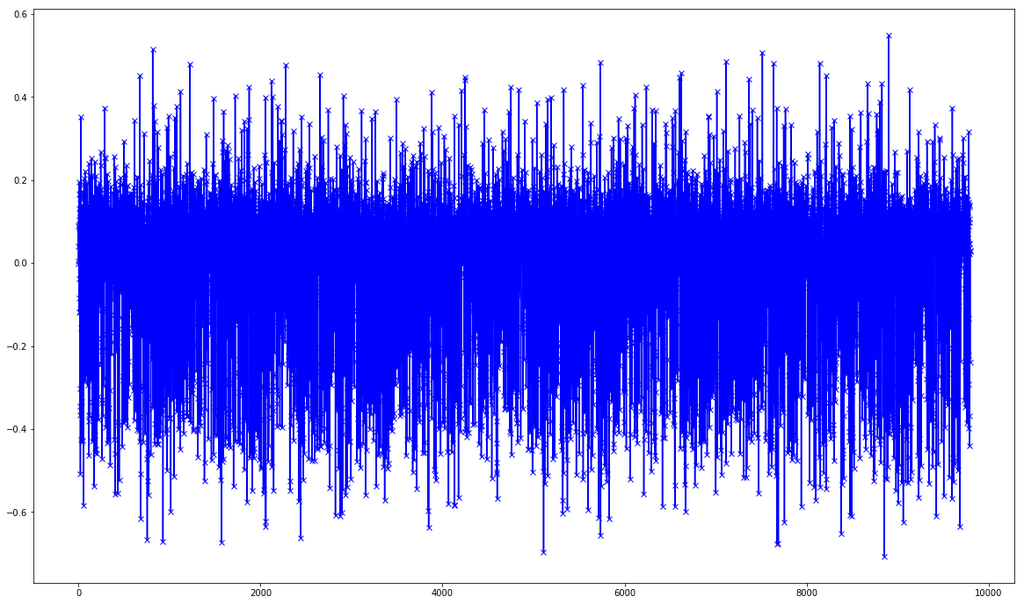

```python
# plot differences over the data points
plt.rcParams['figure.figsize']=(20,12)
plt.plot(x, diff, c='b', marker='x', label='rf')
plt.show()
```

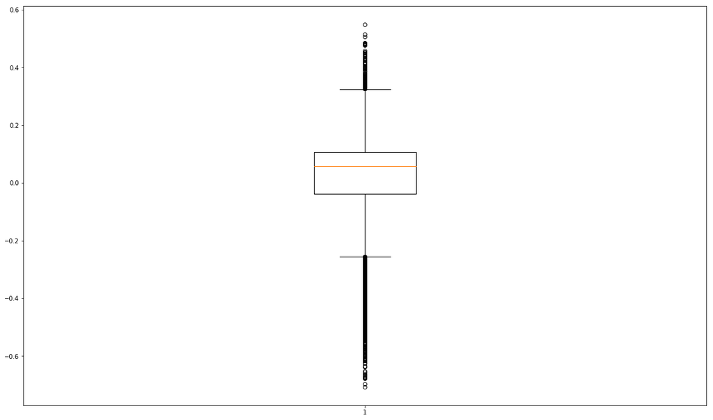

```python
# plot the box and whisker for those differences
plt.boxplot(diff)
plt.show()
```

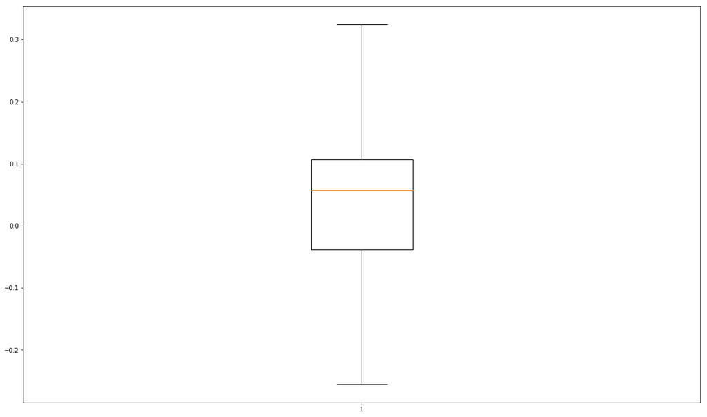

```python
# box and whisker (no outliers)
plt.boxplot(diff, showfliers=False)
plt.show()
```